# Visualizing data with ggplot2

Data Carpentry contributors

```r
download.file("http://datacarpentry.github.io/dc_zurich/data/portal_data_joined.csv",
              "data/portal_data_joined.csv")
surveys_complete <- read.csv(file = "data/portal_data_joined.csv")
```

In this lesson, we will be using functions from the ggplot2 package to create plots. There are plotting capabilities that come with R, but ggplot2 provides a consistent and powerful interface that allows you to produce high quality graphics rapidly, allowing an efficient exploration of your datasets. The functions in base R have different strengths, and are useful if you are trying to draw very specific plots, in particular if they are plots that are not representation of statistical graphics.

## Plotting with ggplot2

With ggplot, plots are build step-by-step in layers. This layering system is based on the idea that statistical graphics are mapping from data to aesthetic attributes (color, shape, size) of geometric objects (points, lines, bars). The plot may also contain statistical transformations of the data, and is drawn on a specific coordinate system. Faceting can be used to generate the same plot for different subsets of the dataset.

To build a ggplot we need to:

- bind plot to a specific data frame

```r
ggplot(surveys_complete)
```

- define aestetics (`aes`), that maps variables in the data to axes on the plot or to plotting size, shape color, etc.,
- add `geoms` – graphical representation of the data in the plot (points, lines, bars). To add a geom to the plot use `+` operator:

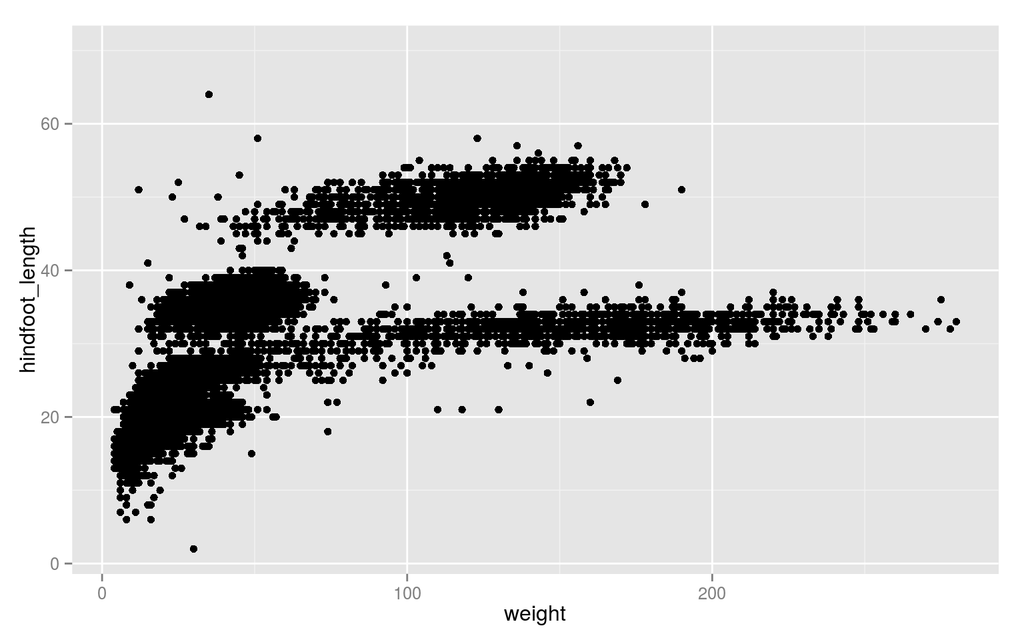

```r
ggplot(surveys_complete, aes(x = weight, y = hindfoot_length)) +
  geom_point()
```

We can reduce over-plotting by adding some jitter:

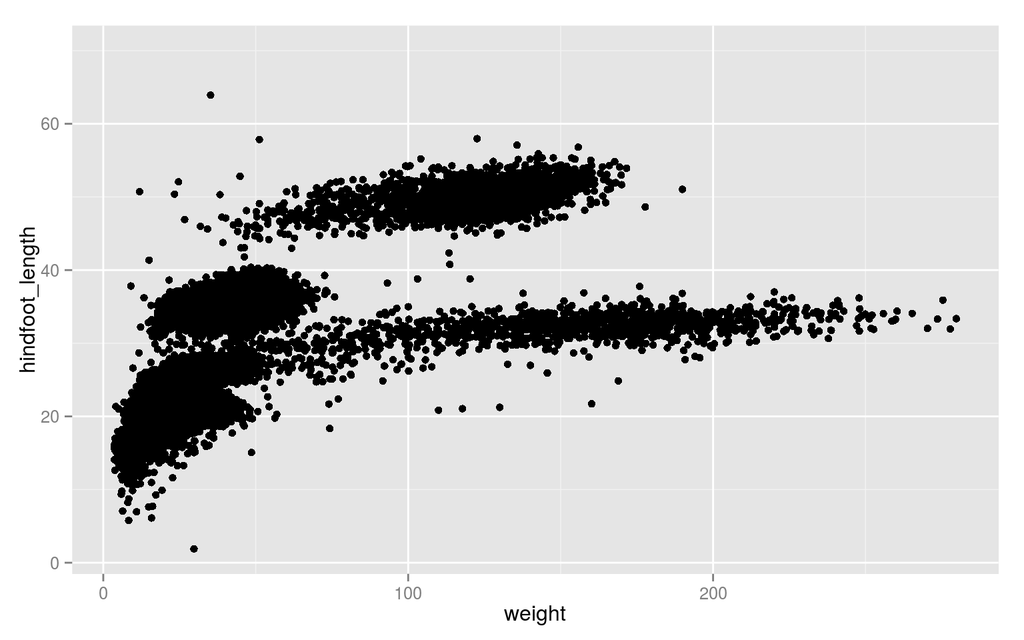

```r
ggplot(surveys_complete, aes(x = weight, y = hindfoot_length)) +
  geom_point(position = position_jitter())
```

We can add additional aesthetic values according to other properties from our dataset. For instance, if we want to color points differently depending on the species.

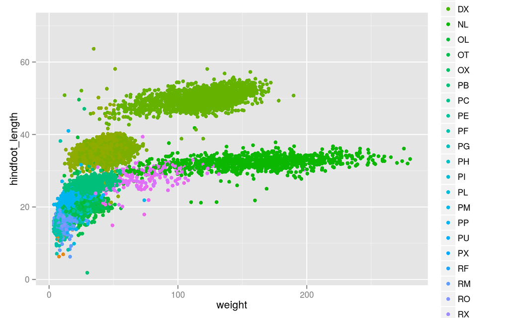

```r
ggplot(surveys_complete, aes(x = weight, y = hindfoot_length, colour = species_id)) +
  geom_point(position = position_jitter())
```

We can make the points more transparent so we can assess the overplotting.

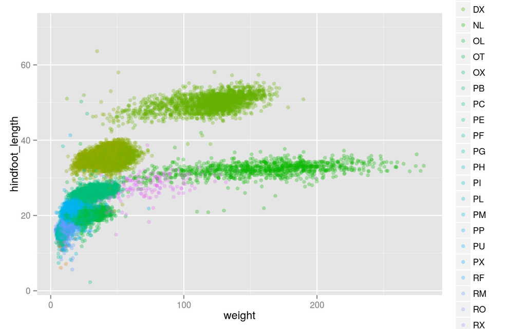

```r
ggplot(surveys_complete, aes(x = weight, y = hindfoot_length, colour = species_id)) +
  geom_point(alpha = 0.3,  position = position_jitter())
```

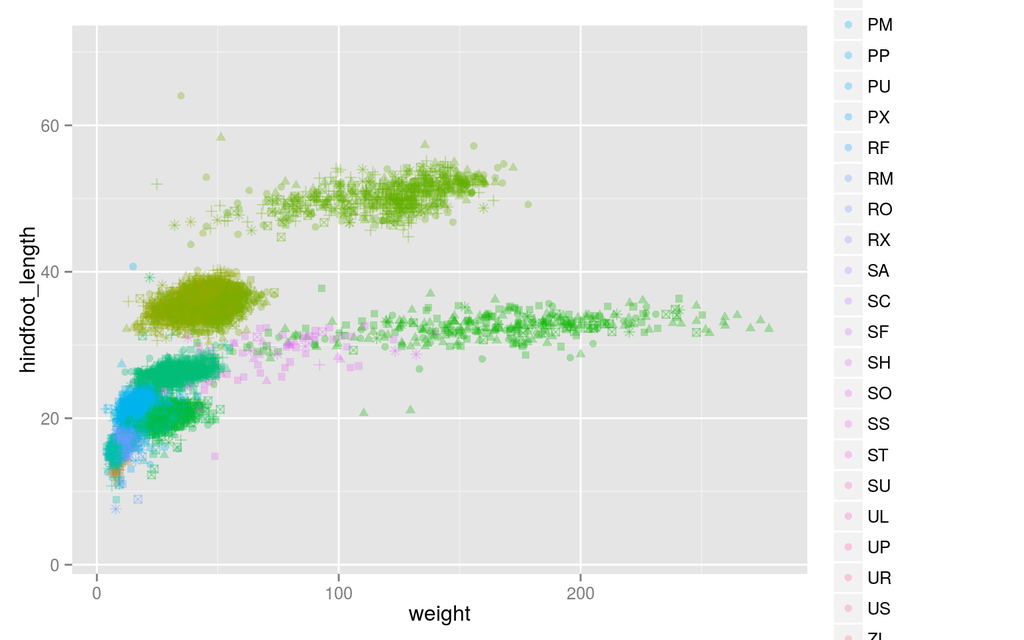

```r
ggplot(surveys_complete, aes(x = weight, y = hindfoot_length, colour = species_id, shape = as.factor(plot_id))) +
  geom_point(alpha = 0.3,  position = position_jitter())
```

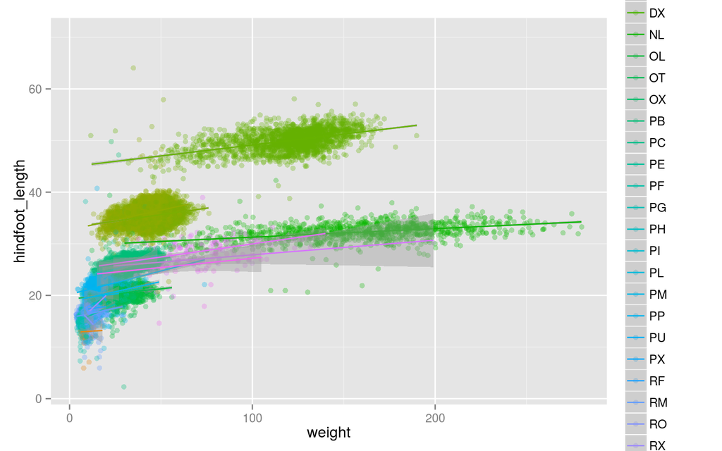

```r
ggplot(surveys_complete, aes(x = weight, y = hindfoot_length, colour = species_id)) +
  geom_point(alpha = 0.3,  position = position_jitter()) + stat_smooth(method = "lm")
```

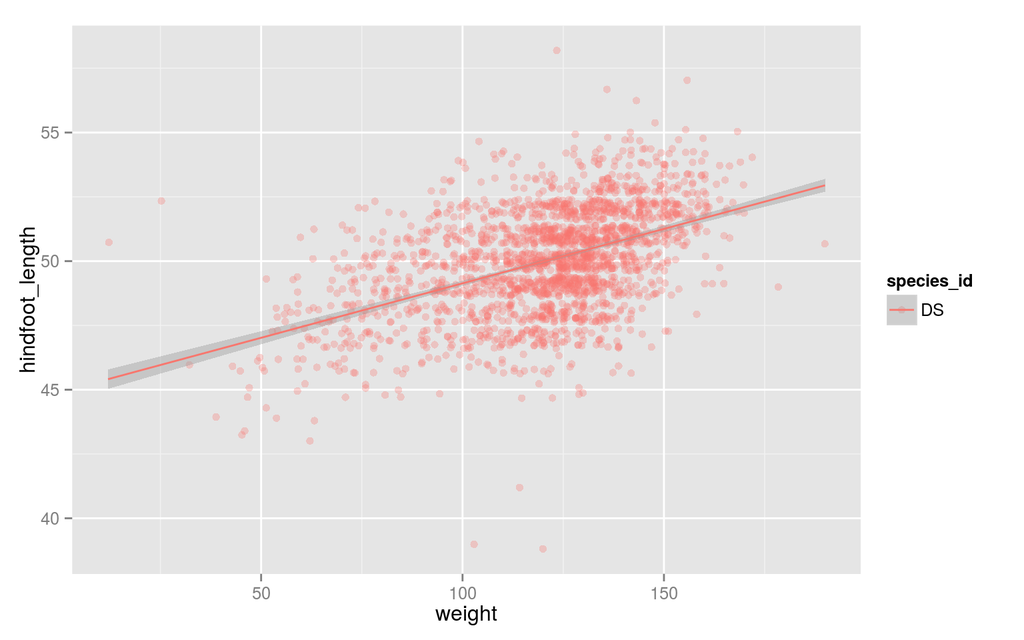

```r
surveys_complete %>%
  filter(species_id == "DS") %>%
  ggplot(aes(x = weight, y = hindfoot_length, colour = species_id)) +
  geom_point(alpha = 0.3,  position = position_jitter()) + stat_smooth(method = "lm")
```

```r
## ggplot(subset(surveys_complete,  species_id == "DS"), aes(x = weight, y = hindfoot_length, colour = species_id)) +
##  geom_point(alpha = 0.3,  position = position_jitter()) + stat_smooth(method = "lm")
```

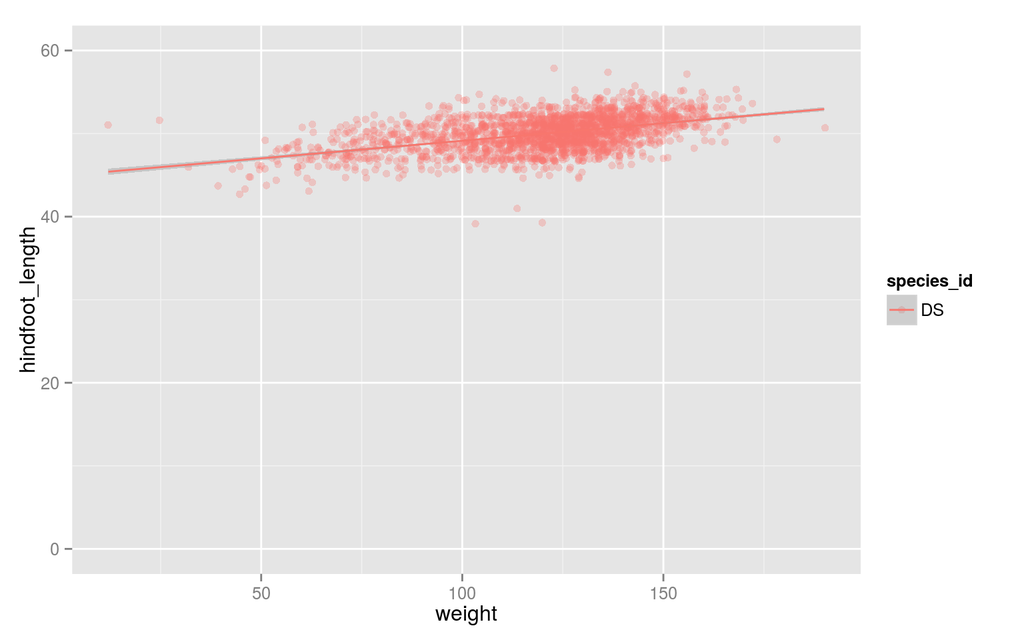

```r
ggplot(subset(surveys_complete, species_id == "DS"),
       aes(x = weight, y = hindfoot_length, colour = species_id)) +
  geom_point(alpha = 0.3,  position = position_jitter()) + stat_smooth(method = "lm") +
  ylim(c(0, 60))
```

Using `ylim` subsets the data to be represented:

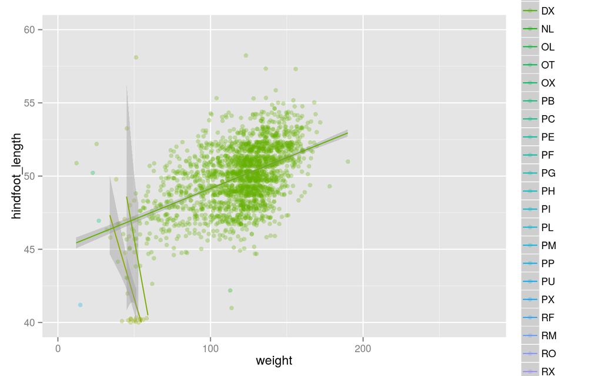

```r
ggplot(surveys_complete,
       aes(x = weight, y = hindfoot_length, colour = species_id)) +
  geom_point(alpha = 0.3,  position = position_jitter()) + stat_smooth(method = "lm") +
  ylim(c(40, 60))
```

while setting limits with `coord_cartesian` acts a magnifying glass:

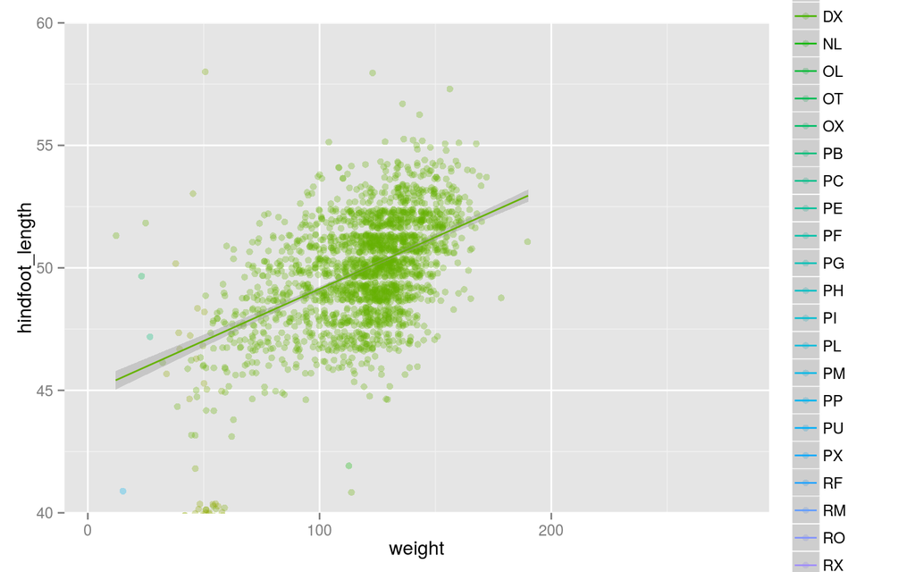

```r
ggplot(surveys_complete,
       aes(x = weight, y = hindfoot_length, colour = species_id)) +
  geom_point(alpha = 0.3,  position = position_jitter()) + stat_smooth(method = "lm") +
  coord_cartesian(ylim = c(40, 60))
```

## Boxplot

Visualising the distribution of weight within each species.

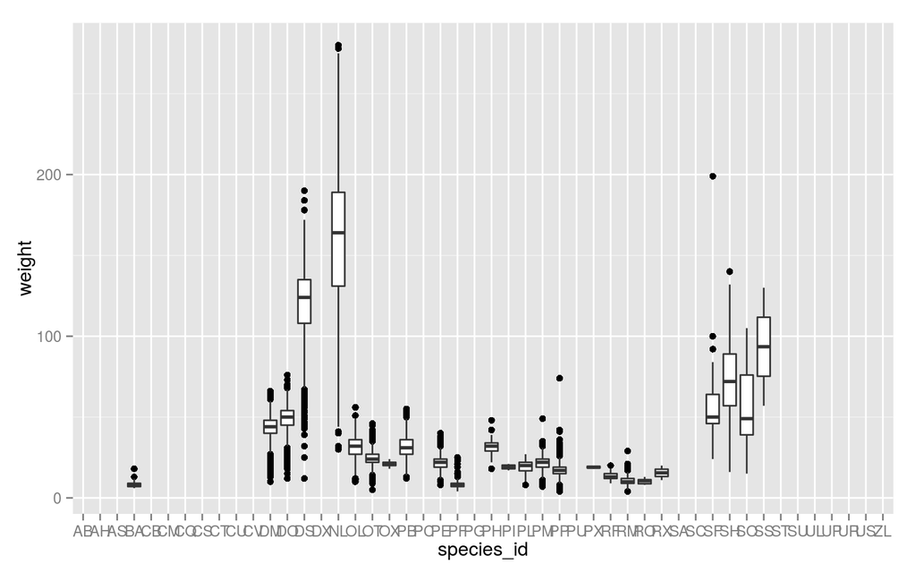

```r
ggplot(surveys_complete, aes(x = species_id, y = weight)) +
  geom_boxplot()
```

By adding points to boxplot, we can see particular measurements and the abundance of measurements.

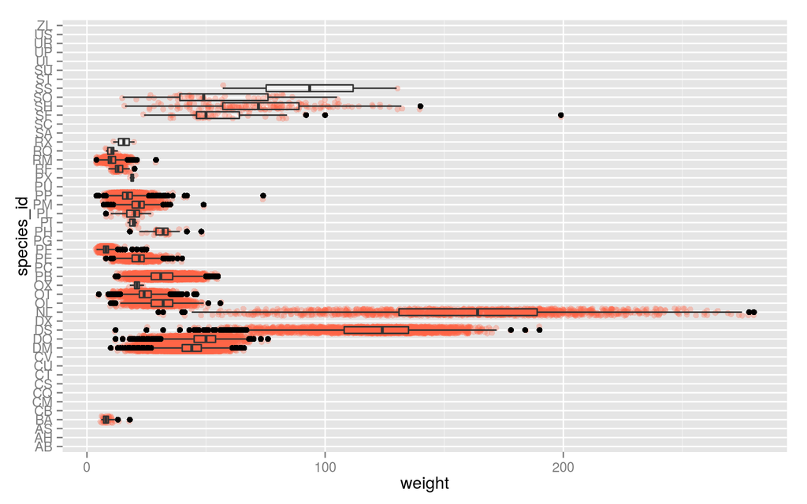

```r
ggplot(surveys_complete, aes(x = species_id, y = weight)) +
  geom_point(alpha=0.3, color="tomato", position = "jitter") +
  geom_boxplot(alpha=0) + coord_flip()
```

### Challenge

> Create boxplot for `hindfoot_length`, and change the color of the points. Replace the boxplot by a violin plot Add the layer `coord_flip()`

## Faceting

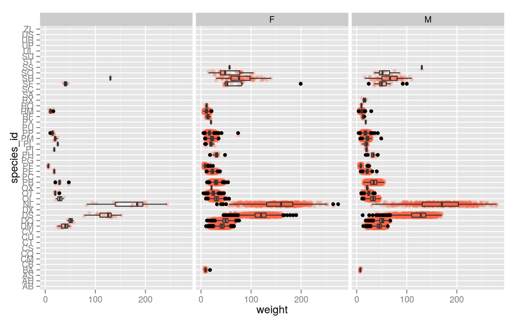

```r
ggplot(surveys_complete, aes(species_id, weight)) +
  geom_point(alpha=0.3, color="tomato", position = "jitter") +
  geom_boxplot(alpha=0) + coord_flip() + facet_wrap( ~ sex)
```

### Challenge

> Modify the data frame so we only look at males and females Change the colors, so points for males and females are different Change the data frame to only plot three species of your choosing

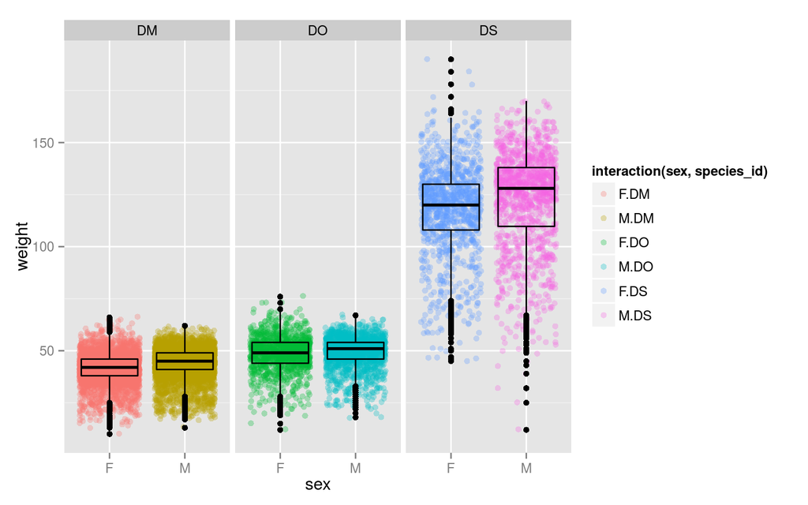

```r
ggplot(subset(surveys_complete, species_id %in% c("DO", "DM", "DS") & sex %in% c("F", "M")),
       aes(x = sex, y = weight,  colour = interaction(sex, species_id))) + facet_wrap( ~ species_id) +
       geom_point(alpha = 0.3, position = "jitter") +
       geom_boxplot(alpha = 0, colour = "black")
```

## barplot

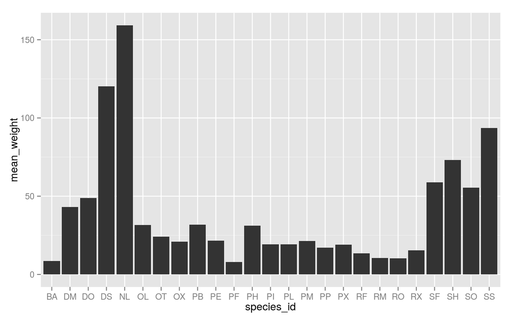

```r
ggplot(surveys_complete, aes(species_id)) + geom_bar()

surveys_complete %>%
  filter(!is.na(weight)) %>%
  group_by(species_id) %>%
  summarize(mean_weight = mean(weight)) %>%
  ggplot(aes(x = species_id, y = mean_weight)) + geom_bar(stat = "identity")
```

[output not shown]

### Challenge

> Repeat the same thing on the hindfoot length instead of the weight

## Plotting time series data

Let’s calculate number of counts per year for each species. To do that we need to group data first and count records within each group.

```r
yearly_counts <- surveys_complete %>%
                 group_by(year, species_id) %>%
                 summarise(count=n())
```

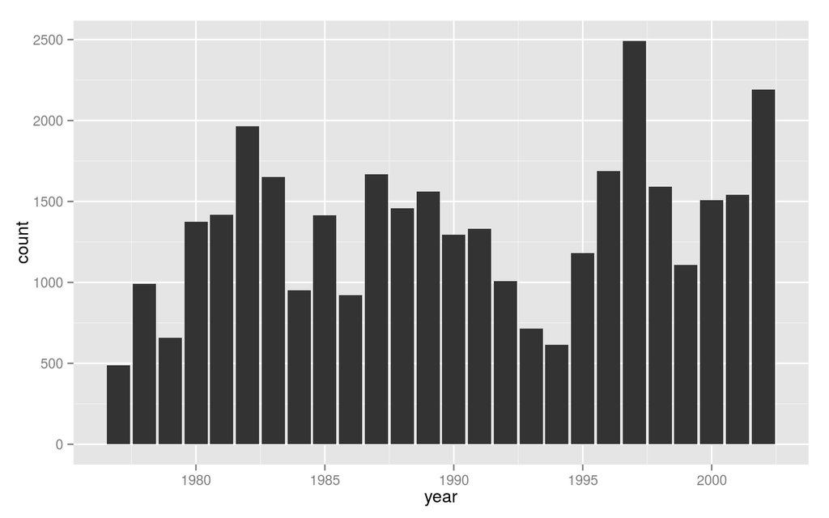

```r
ggplot(yearly_counts, aes(x=year, y=count)) +
  geom_bar(stat = "identity")
```

This is the plot data for all the species together. We need to tell ggplot to split graphed data by `species_id`

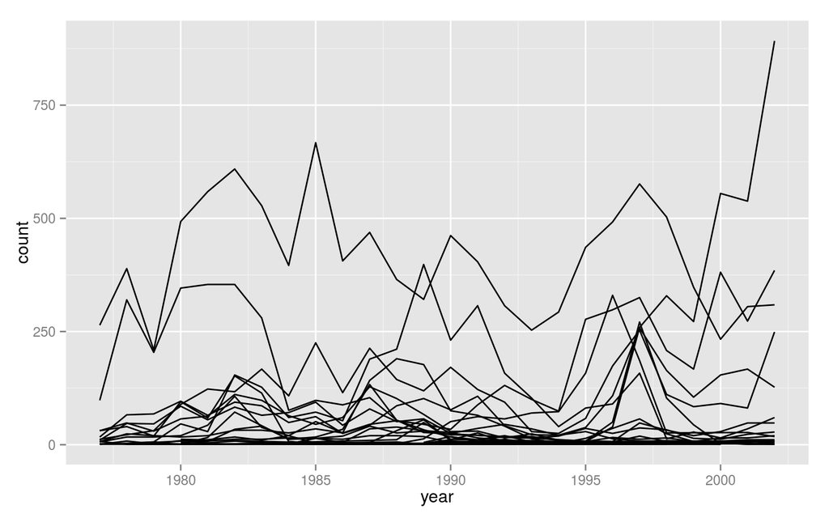

```r
ggplot(yearly_counts, aes(x=year, y=count, group=species_id)) +
  geom_line()
```

We will be able to distiguish species in the plot if we add colors.

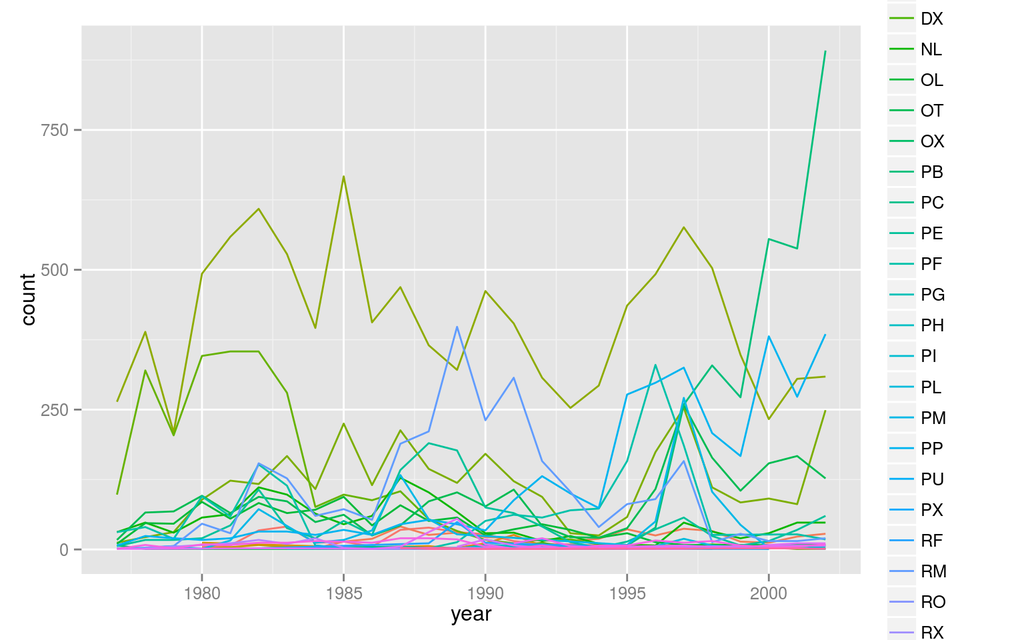

```r
ggplot(yearly_counts, aes(x=year, y=count, group=species_id, color=species_id)) +
  geom_line()
```

### Challenge

> 1. Draw the yearly counts for the species DO, DS, DM
> 2. Draw the yearly counts for each plot type
> 3. Draw the yearly counts for all taxa but Rodents
> 4. Draw the yearly counts for species that have been captured more than 2000 times over the course of the surveys (difficult)
> 5. Draw the yearly counts for the species that have been captured at least 300 times in one year (difficult)

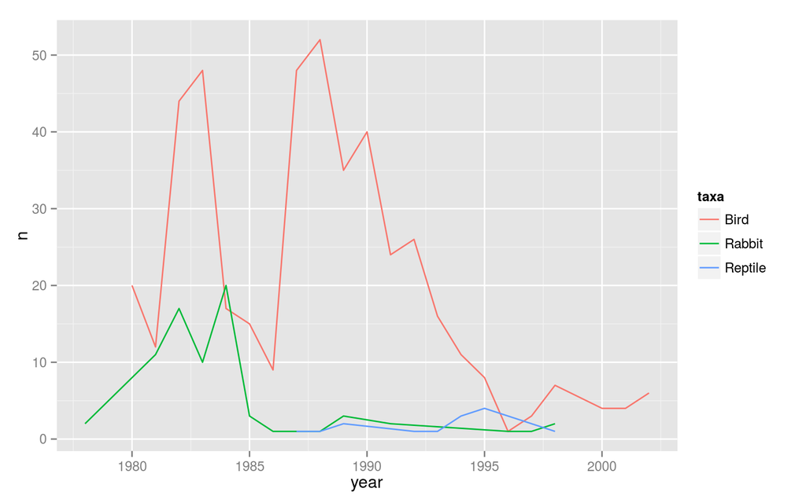

```r
surveys_complete %>%
  group_by(taxa, year) %>%
  tally %>%
  filter(taxa != "Rodent") %>%
  ggplot(aes(x = year, y = n, group = taxa, color = taxa)) +
  geom_line()
```

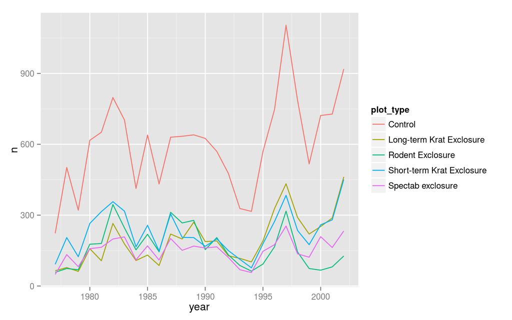

```r
surveys_complete %>%
  group_by(plot_type, year) %>%
  tally %>%
  ggplot(aes(x = year, y = n, group = plot_type, color = plot_type)) +
  geom_line()
```

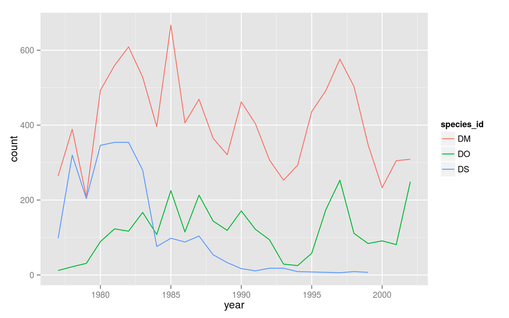

```r
### Easy

yearly_counts %>%
  filter(species_id %in% c("DO", "DS", "DM")) %>%
  ggplot(aes(x = year, y = count, group = species_id, color = species_id)) +
  geom_line()
```

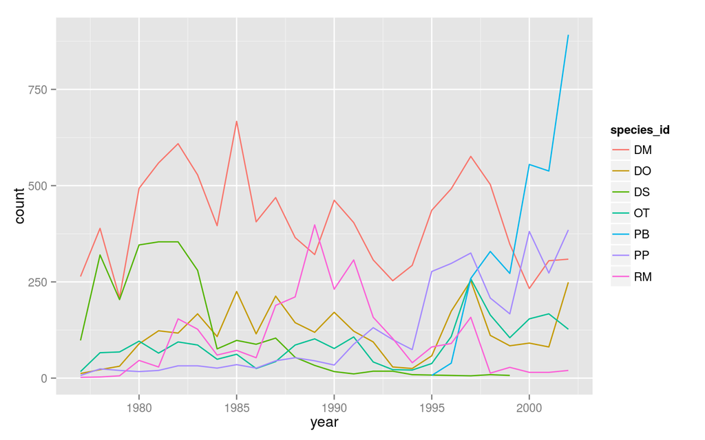

```r
### Difficult

sp_totals <- surveys_complete %>%
  group_by(species_id) %>%
  summarise(count = n()) %>%
  filter(count > 2000) %>%
  .$species_id

yearly_counts %>%
  filter(species_id %in% sp_totals) %>%
  ggplot(aes(x = year, y = count, group = species_id, color = species_id)) +
  geom_line()
```

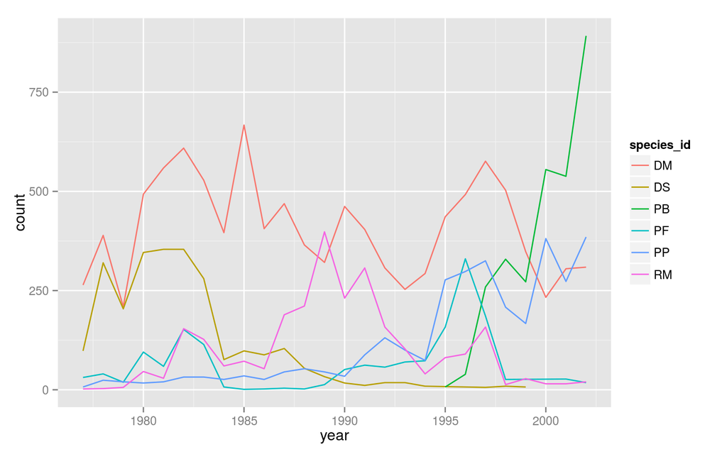

```r
### More difficult

sp_250 <- yearly_counts %>%
  filter(count >=  300) %>%
  ungroup %>%
  select(species_id) %>%
  unique

yearly_counts %>%
  filter(species_id %in% sp_250$species_id) %>%
  ggplot(aes(x = year, y = count, group = species_id, color = species_id)) +
  geom_line()
```

## Resources for going further

- The ggplot2 documentation: http://docs.ggplot2.org/
- The R cookbook website: http://www.cookbook-r.com/
- customizing the aspect of your plots with themes: http://docs.ggplot2.org/dev/vignettes/themes.html